# House Selling Prices

```r
library(tidyverse)
library(MASS)
library(ggplot2)
train <- read.csv("train.csv", stringsAsFactors = TRUE)

#CORRECTS NA TO BE NONE
train <- train %>%
  mutate(Alley = as.character(Alley),
         Alley = replace_na(Alley, "None"),
         Alley = as.factor(Alley)) %>%

  #adds total square feet being first second flr and bsmt
  #also adds if its a rich neghibor hood or not...
  mutate(TotalSF = X1stFlrSF + X2ndFlrSF + TotalBsmtSF,
                RichNbrhd = case_when(Neighborhood %in% c("StoneBr", "NridgHt", "NoRidge") ~ 1,
                             TRUE ~ 0))

#This is total square feet of the house
# lm.sqft <- lm(SalePrice ~ TotalSF, data=train)
# summary(lm.sqft)
# plot(SalePrice ~ TotalSF, data=train)



#30 r^2 is not bad
# lm.fullbath <- lm(SalePrice ~ FullBath, data = train)
# summary(lm.fullbath)

#combined adds a %
# lm.sqft.fullbath <- lm(SalePrice~ TotalSF + FullBath, data = train)
# summary(lm.sqft.fullbath)


#trying grage stuff
# lm.GarageArea <- lm(SalePrice ~ GarageArea, data=train)
# summary(lm.GarageArea)


#pool doesn't add any value...

#make msci into numbers or switches
# train <- train %>%
#   mutate(MiscFeature = case_when(
#     MiscFeature == "MiscFeatureOthr" ~ 1,
#     MiscFeature == "MiscFeatureShed" ~ 2,
#     MiscFeature == "MiscFeatureTenC" ~ 3,
#     TRUE ~ 0  # Keeps other values as NA
#   ))
#
# lm.msic <- lm(SalePrice ~ MiscFeature, data=train)
# lm.msic
# waht is up with adding in + MiscFeature


#final test lms

#
# lm1 <- lm(SalePrice ~ TotalSF + GarageArea + RichNbrhd + OverallQual + KitchenQual + ExterQual + GrLivArea, data = train)
# summary(lm1)
```

This is an analysis on what factors are significant in predicting house prices. The data is taken from a Kaggle competition. Many different variables were tested, but the model selected uses some of the most predictive variables.

## Final Model

*model results were not pandered for clarity.

```r
#try combining garage area in to total sf
train <- train %>%
  mutate(TotalSF = X1stFlrSF + X2ndFlrSF + TotalBsmtSF + GarageArea)

lm1 <- lm(SalePrice ~ (TotalSF + YearBuilt)*RichNbrhd + OverallQual, data=train)
summary(lm1)
```

```
##
## Call:
## lm(formula = SalePrice ~ (TotalSF + YearBuilt) * RichNbrhd +
##     OverallQual, data = train)
##
## Residuals:
##     Min      1Q  Median      3Q     Max
## -415245  -15692   -1130   12911  185944
##
## Coefficients:
##                       Estimate Std. Error t value Pr(>|t|)
## (Intercept)         -5.841e+05  6.694e+04  -8.727  < 2e-16 ***
## TotalSF              3.102e+01  1.347e+00  23.039  < 2e-16 ***
## YearBuilt            2.776e+02  3.521e+01   7.885 6.11e-15 ***
## RichNbrhd           -3.482e+06  8.898e+05  -3.914 9.50e-05 ***
## OverallQual          1.933e+04  1.000e+03  19.326  < 2e-16 ***
## TotalSF:RichNbrhd    5.950e+01  3.299e+00  18.035  < 2e-16 ***
## YearBuilt:RichNbrhd  1.639e+03  4.450e+02   3.683 0.000239 ***
## ---
## Signif. codes:  0 '***' 0.001 '**' 0.01 '*' 0.05 '.' 0.1 ' ' 1
##
## Residual standard error: 33070 on 1453 degrees of freedom
## Multiple R-squared:  0.8274, Adjusted R-squared:  0.8267
## F-statistic:  1161 on 6 and 1453 DF,  p-value: < 2.2e-16
```

## Plots

This is how total square footage affects sales price with an interaction showing rich neighborhoods. An increase in total square footage drastically increases the price with rich neighborhoods increasing in price even more quickly. There are two houses that fell victim to the 2008 housing crisis. The model doesn’t account for this but it’s worth noting that they pull down the red trend line a bit.

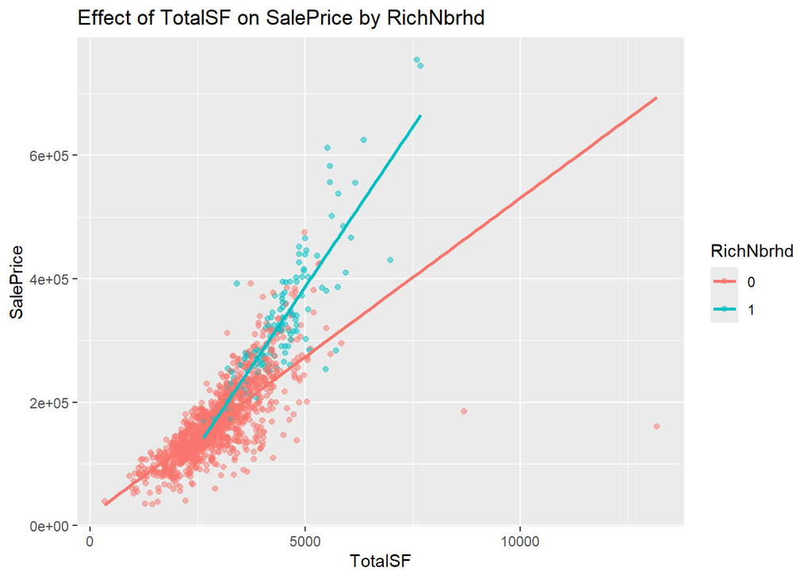

```r
ggplot(train, aes(x=TotalSF, y=SalePrice, color=factor(RichNbrhd))) +
  geom_point(alpha=0.5) +
  geom_smooth(method="lm", aes(group=RichNbrhd), se=FALSE) +
  labs(title="Effect of TotalSF on SalePrice by RichNbrhd", color="RichNbrhd")
```

This is how year built predicts sale price with an interaction showing rich neighborhoods. As houses are newer they get more expensive. Rich neghiborhoods apear to be mostly newer houses. No suprise there.

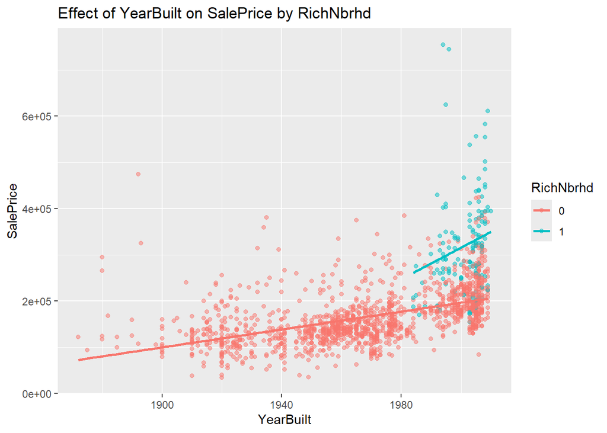

```r
ggplot(train, aes(x=YearBuilt, y=SalePrice, color=factor(RichNbrhd))) +
  geom_point(alpha=0.5) +
  geom_smooth(method="lm", aes(group=RichNbrhd), se=FALSE) +
  labs(title="Effect of YearBuilt on SalePrice by RichNbrhd", color="RichNbrhd")
```

This is how overall quality predicts sales price. It appears to be more categorical. In future studies It might be worth considering making it into a factor and having it work as a switch for the other varaibles.

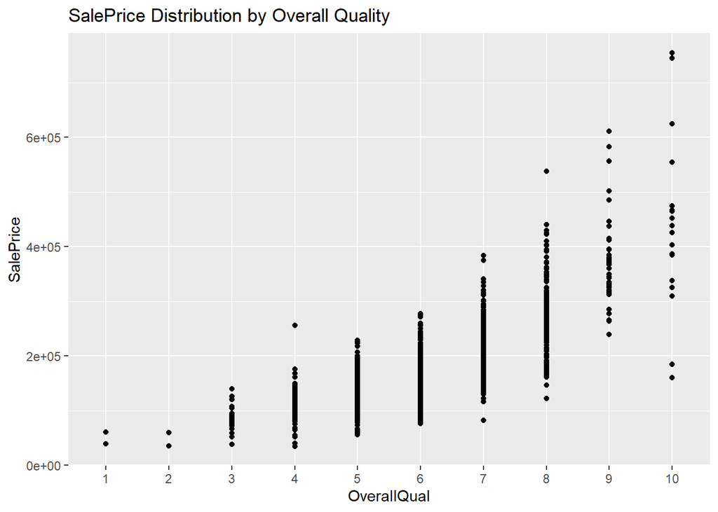

```r
ggplot(train, aes(x=factor(OverallQual), y=SalePrice)) +
  geom_point() +
  labs(title="SalePrice Distribution by Overall Quality", x="OverallQual")
```